# Domača naloga 2

Bayesova statistika

Alen Kahteran

30. 12. 2020

# 1. Popravljen algoritem

```r
### Parametri (hiper)apriornih porazdelitev
sigma20 <- 100
nu0 <- 1
eta20 <- 100
kappa0 <- 1
mu0 <- 50
tau20 <- 25

# novo dodane vrednosti iz navodil
a <- 1
b <- 1/100
alpha <- 1
k.max <- 1000

### Pripravimo si kolicine, ki jih bomo potrebovali iz podatkov
x       <- pod
m       <- length(pod.sole$school)
n       <- pod.sole$n
x.povpr <- pod.sole$povprecje
# dodana varianca za vsako skupino posebej
x.var   <- pod.sole$varianca

### Dolocimo si zacetne vrednosti
muGroups     <- x.povpr
sigma2Groups <- x.var # tu dolocimo sigme za vsako skupino posebej
mu           <- mean(muGroups)
eta2         <- var(muGroups)

### Pripravimo si prostor za shranjevanje
n.iter <- 5000

muGroups.all         <- matrix(nrow=n.iter, ncol=m)
sigma2Groups.all     <- matrix(nrow=n.iter, ncol=m) # novo dodano
sigma20.all          <- rep(NA, n.iter) # novo dodano
mu.all               <- rep(NA, n.iter)
eta2.all             <- rep(NA, n.iter)
nu0.all              <- rep(NA, n.iter) # novo dodano
### Dolocimo si zacetne vrednosti
muGroups.all[1,]     <- muGroups
sigma2Groups.all[1,] <- sigma2Groups # novo dodano
sigma20.all[1]       <- sigma20 # novo dodano
mu.all[1]            <- mu
eta2.all[1]          <- eta2
nu0.all[1]           <- nu0 # novo dodano

# seme za ponovljivost
set.seed(8)
### Pozenemo Gibbsov vzorcevalnik
for(s in 1:n.iter){

    # Vzorčimo muGroups
    # Vzorčimo mu kjer ni več sigma2 ampak sigma2Groups[j] v enačbi
    for(j in 1:m){
    muGroups[j] <- rnorm(1,
                         mean = (x.povpr[j]*n[j]/sigma2Groups[j] + mu/eta2) /
                             (n[j]/sigma2Groups[j] + 1/eta2),
                         sd=sqrt(1/(n[j]/sigma2Groups[j] + 1/eta2)))
    }

    # Vzorčimo sigma2Groups tokrat, namesto sigma2.
    # po skupinah (po navodilih)
    for(j in 1:m){
        sigma2Groups[j] <- 1/rgamma(1,
                                    (nu0+n[j])/2,
                                    (nu0*sigma20 + sum((x[x[, 1] == j, 2] -
                                                            muGroups[j])^2))/2)
    }

    # Vzorčimo sigma20
    # to je dodano po navodilih
    sigma20 <- rgamma(1,
                      a + m*nu0/2,
                      b + nu0*sum(1/sigma2Groups)/2)

    # Vzorčimo mu
    # ostane nespremenjeno
    mu <- rnorm(1,
                mean=(mean(muGroups)*m/eta2 + mu0/tau20) /
                    (m/eta2 + 1/tau20),
                sd=sqrt(1/(m/eta2 + 1/tau20)))

    # Vzorčimo eta2
    # ostane nespremenjeno
    ss   <- kappa0*eta20 + sum((muGroups-mu)^2)
    eta2 <- 1/rgamma(1, (kappa0+m)/2, ss/2)

    # Vzorčimo nu0
    # dodano iz navodil
    k <- 1:k.max
    logp.nu0 <- m * (0.5 * k * log(k*sigma20/2) - lgamma(k/2)) +
        (k/2 - 1) * sum(log(1/sigma2Groups)) -
        k*(alpha + 0.5*sigma20*sum(1/sigma2Groups))
    nu0 <- sample(k, 1, prob=exp(logp.nu0 - max(logp.nu0)))

    # Shranimo nove parametre
    muGroups.all[s,]     <- muGroups
    sigma2Groups.all[s,] <- sigma2Groups
    sigma20.all[s]       <- sigma20
    mu.all[s]            <- mu
    eta2.all[s]          <- eta2
    nu0.all[s]           <- nu0
}
```

# 2. Preučevanje rezultatov

Najprej si poglejmo celotne *trace plot*-e za $\mu_j$ kjer sem za $j$ izbral vrednosti $2, 8, 9$ in $42$.

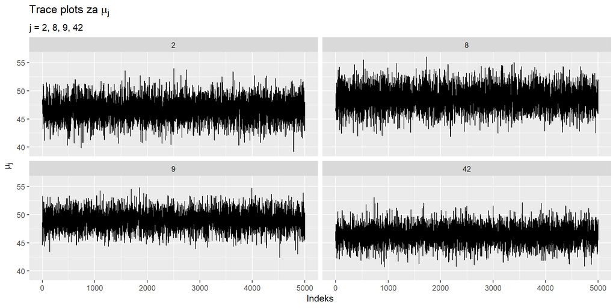

Izgleda da smo dosegli konvergenco. Lepo je videti primerjavo med šolo $9$ in $42$, kako se konvergenca dogaja okrog različne vrednosti $\mu$. *Burn-in* ni opazen v nobenem izmed izbranih primerov, kar je za pričakovati saj smo za začetno vrednost izbrali vzorčno povprečje posamezne skupine. Mogoče bo *Burn-in* bolj opazen na grafih z manj členi zaporedja. Poglejmo si torej enake slike le s $500$ členi zaporedja.

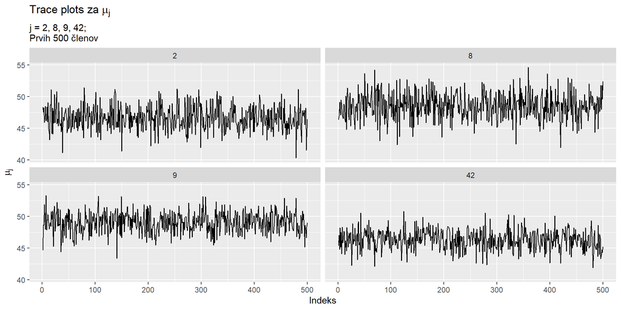

Podobno kot prej, za izbrane $\mu_j$ vrednosti, ne vidimo *Burn-in* dela. Za $\mu_j$ izgledajo verige v redu. Poglejmo si še podobne grafe za $\sigma_j^2$.

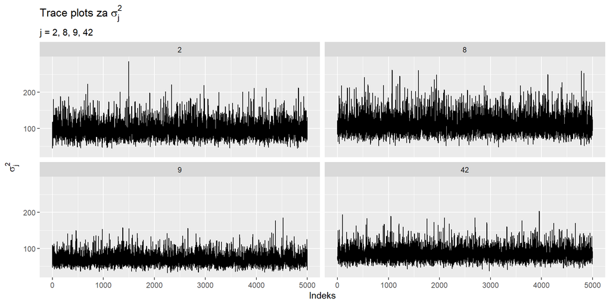

Podobno kot za $\mu_j$, zgleda da smo dosegli konvergenco. *Burn-in* ravno tako ni opazen v nobenem izmed izbranih primerov in ravno tako kot pri $\mu_j$, smo tudi tu določili začetne vrednosti variance, kar vzorčne variance posameznih skupin. Največ kar opazimo je to da je varianca v skupinah $2$ in $8$ večja kot v skupinah $9$ in $42$ (vrednosti so nekoliko višje). Zopet si poglejmo če bomo opazili *burn-in* pri prvih 500 členih zaporedja.

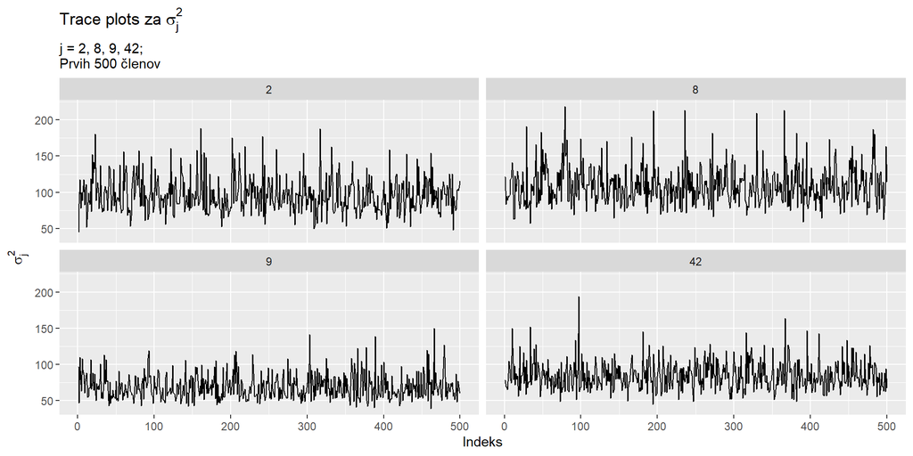

Zopet ne vidimo *burn-in* dela tako da lahko rečemo da so tudi tu verige v redu. Poglejmo si podobne grafe še za hiperparametre.

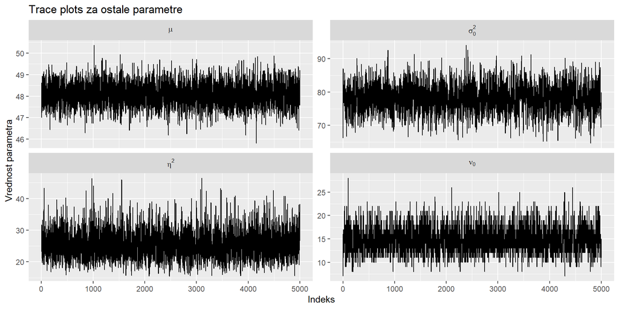

Pri hiperparametrih ravno tako zgleda da smo dosegli konvergenco. Zopet ne vidimo *burn-in* dela. Največ kar je opazno je diskretnost hiperparametra $\nu_0$. Ponovno si poglejmo še grafe prvih $500$ členov zaporedja.

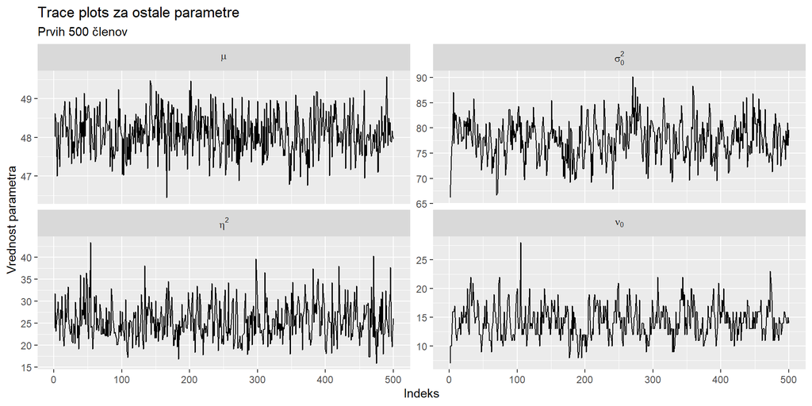

Ponovno ni videti *burn-in* dela verig, zato bomo ohranili celotne verige.

Poglejmo si še “stabilnost” naših verig. Verige razdelimo na $10$ enako velikih delov. Podvzorec določimo kot $\frac{1}{10}$ zaporednih členov celotne verige. Za tem primerjamo njihove porazdelitve. Najprej si poglejmo slike za $\mu_j$.

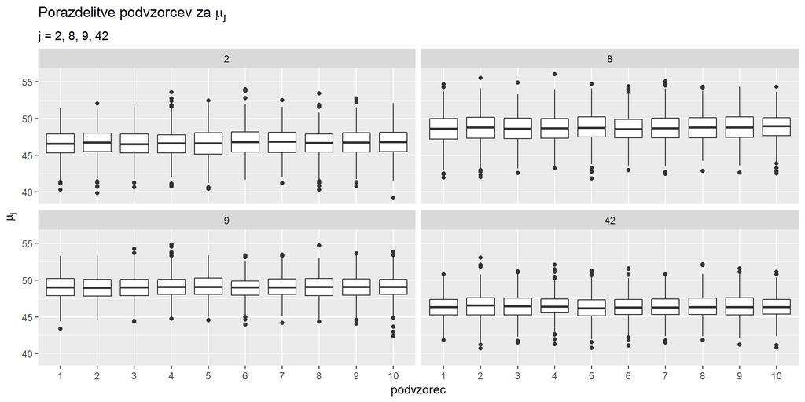

Podobno kot prej, vidimo razlike med posameznimi skupinami, medtem ko so podvzorci znotraj skupine “stabilni”. Poglejmo si podobno sliko še za $\sigma_j^2$.

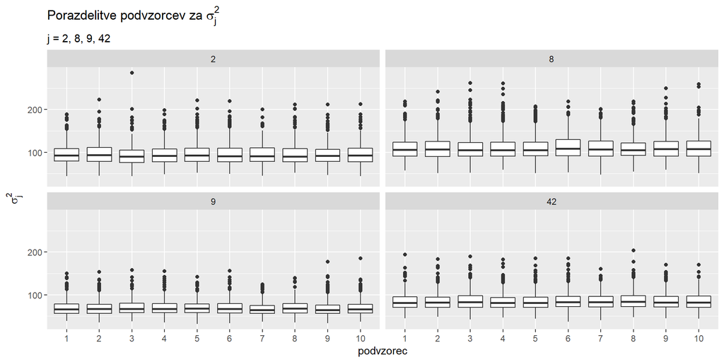

Ravno tako opazimo razlike med posameznimi skupinami. Če mogoče ni bilo opazno na *trace plot*-ih je tu precej bolje videti da so porazdelitve nekoliko asimetrične. To je tudi smiselno saj jih vzorčimo iz inverzne gamma porazdelitve, ki je asimetrična. Poglejmo si še podvzorce za hiperparametre.

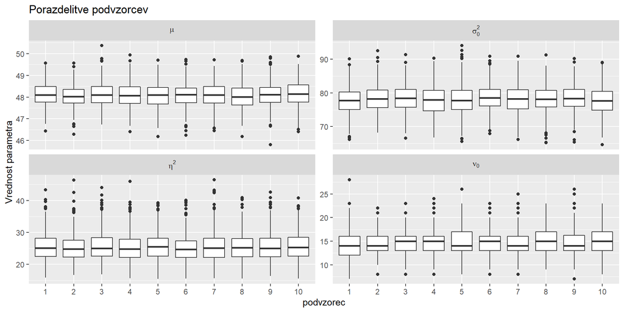

Kar se “stabilnosti” tiče ravno tako ne vidimo težav. Na prvi pogled izgleda, da bi lahko težavo predstavljali podvzorci za $\nu_0$, vendar se “poskakovanje” mediane dogaja zaradi diskretnosti.

Poglejmo si še prikaze avtokorelacij za vse naše (hiper)parametre.

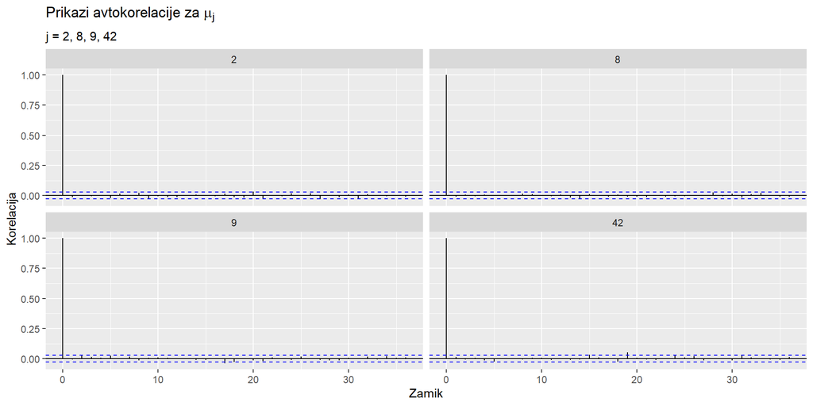

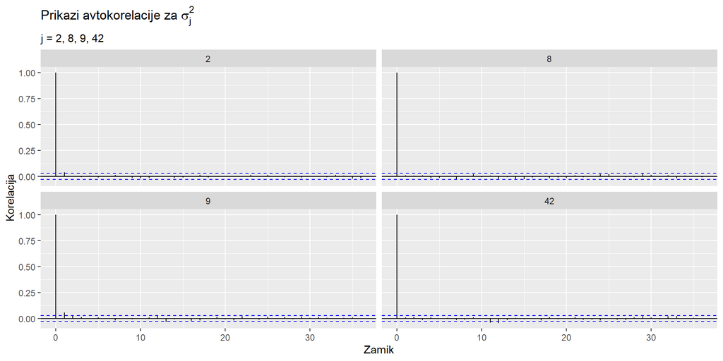

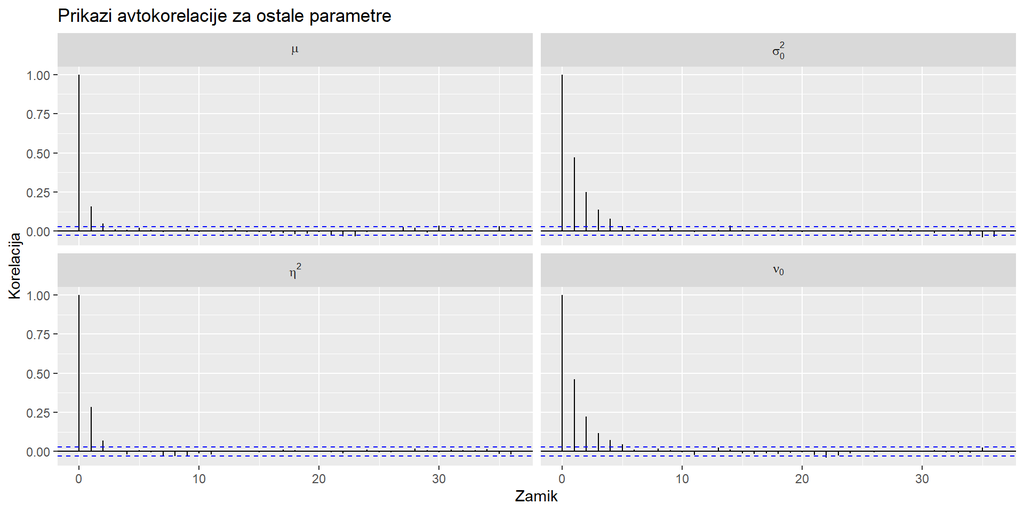

Večjih težav z avtokorelacijo pri $\mu_j$ in $\sigma_j^2$, ni videti. Pri hiperparametrih vidimo da gre pri vseh parametrih korelacija z manjšo zakasnitvijo k $0$. Smiselno si je pogledati še *effective sample size* vseh parametrov. Zraven je dodana še “standardna napaka” (MCSE - Monte Carlo Standard Error).

| (hiper)parameter | Effective sample size | MCSE |
| --- | --- | --- |
| $\mu_2$ | 5000.00 | 0.0275 |
| $\mu_8$ | 5000.00 | 0.0288 |
| $\mu_9$ | 5000.00 | 0.0230 |
| $\mu_{42}$ | 5000.00 | 0.0231 |
| $\sigma^2_2$ | 4621.23 | 0.3573 |
| $\sigma^2_8$ | 5000.00 | 0.3940 |
| $\sigma^2_9$ | 4235.68 | 0.2643 |
| $\sigma^2_{42}$ | 5000.00 | 0.2787 |
| $\mu$ | 3466.99 | 0.0092 |
| $\sigma^2_0$ | 1674.58 | 0.0997 |
| $\eta^2$ | 2776.79 | 0.0821 |
| $\nu_0$ | 1848.97 | 0.0639 |

Vidimo da je *effective sample size* višji pri že vidno boljših prikazih avtokorelacije. Pri hiperparametrih kjer smo že videli težavo je tudi *effective sample size* nižji. Velikost *MCSE* je smiselno interpretirati v sklopu dejanskih vrednosti (hiper)parametrov, kar si bomo pogledali v naslednjem poglavju.

# 3. Robne aposteriorne porazdelitve

Poglejmo si torej najprej robne aposteriorne porazdelitve za $\mu_j$ in $\sigma_j^2$.

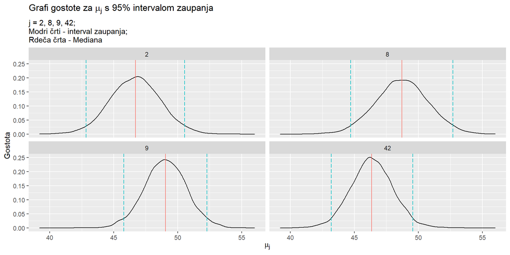

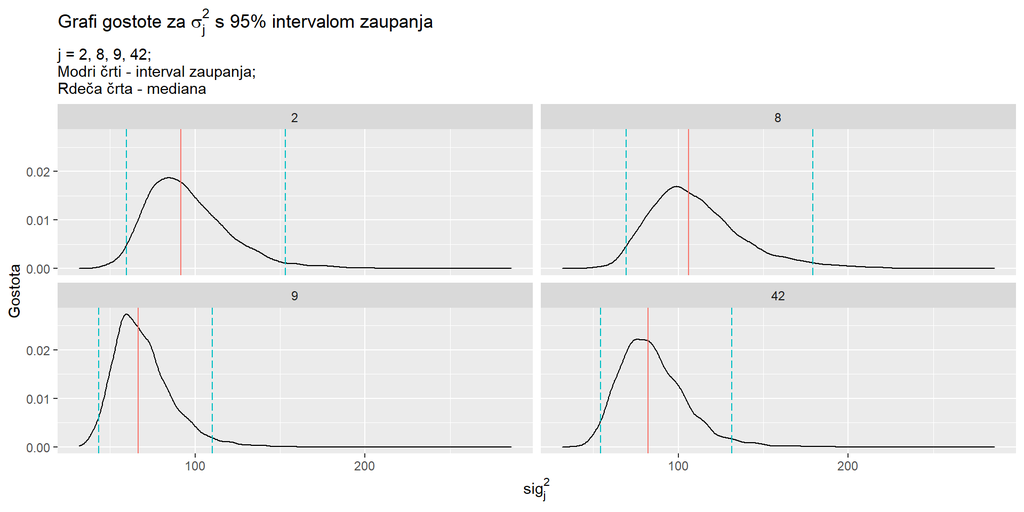

Pričakovano, so $\mu_j$ porazdelitve normalne, saj jih vzorčimo iz normalne porazdelitve. Podobno velja za $\sigma_j^2$ saj vzorčimo iz inverzne gamma porazdelitve. Te krivulje predstavljajo gostote za povprečje oz. za varianco ocen iz matematike posamezne šole.

Hiperparametri so nekoliko težji za razumeti, in nisem niti ravno prepričan če si jih pravilno interpretiram. Poglejmo si najprej porazdelitve hiperparametrov.

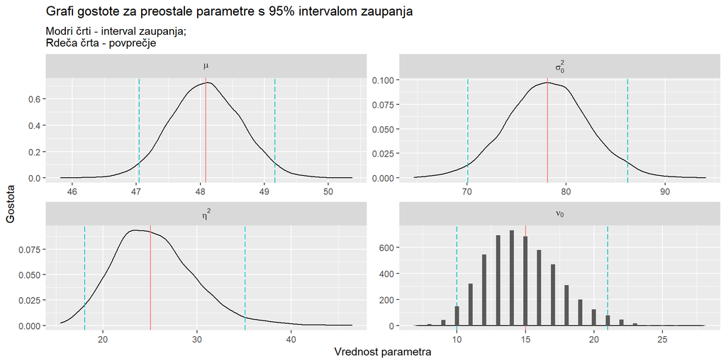

$\mu$ je lepo simetrično normalno porazdeljen, kar je lepo razvidno iz slike. $\mu$ predpostavljam da si lahko razlagamo kot povprečje vseh šol (oz. skupin).

$\sigma_0^2$ je tudi lepo porazdeljen, bi skoraj rekel da normalno, vendar glede na navodila vemo da je porazdeljen po gama porazdelitvi. Gama porazdelitev se pri dovolj velikih parametrih lahko aproksimira z normalno porazdelitvijo vendar to ni bistvo te naloge. $\sigma_0^2$ si predstavljam kot porazdelitev povprečij varianc skupin. Torej kot nekakšno skupno varianco vsem skupinam.

$\eta^2$ je že vizualno asimetrična, tudi smiselno saj izhaja iz inverzne gama porazdelitve. Razlagam si ga kot varianco povprečij skupin (oz. šol v našem primeru).

$\nu_0$ je diskretne oblike poleg tega pa še asimetričen. Razlagam si ga kot nekakšen povezovalni faktor, ki pove koliko informacij (zdi se mi da variance) se “deli” med skupinami.

Poglejmo si še $95\%$ intervale zaupanja za vse izbrane parametre in hiperparametre. Dodana je še mediana kot izbrana središčna vrednost zaradi asimetričnosti nekaterih porazdelitev, ter ti. MCSE, ki smo ga že izračunali višje.

| (hiper)parameter | 2.5% | Mediana | 97.5% | MCSE |
| --- | --- | --- | --- | --- |
| $\mu_{2}$ | 42.85 | 46.69 | 50.55 | 0.03 |
| $\mu_{8}$ | 44.71 | 48.72 | 52.70 | 0.03 |
| $\mu_{9}$ | 45.79 | 49.04 | 52.29 | 0.02 |
| $\mu_{42}$ | 43.19 | 46.35 | 49.57 | 0.02 |
| $\sigma_{2}^2$ | 59.45 | 91.58 | 153.03 | 0.36 |
| $\sigma_{8}^2$ | 69.44 | 106.09 | 179.09 | 0.39 |
| $\sigma_{9}^2$ | 43.30 | 66.42 | 110.25 | 0.26 |
| $\sigma_{42}^2$ | 54.32 | 82.31 | 131.49 | 0.28 |
| $\mu$ | 47.04 | 48.09 | 49.17 | 0.01 |
| $\sigma_0^2$ | 70.08 | 78.14 | 86.23 | 0.10 |
| $\eta^2$ | 18.05 | 25.03 | 35.10 | 0.08 |
| $\nu_0$ | 10.00 | 15.00 | 21.00 | 0.06 |

MCSE je, glede na vrednosti (hiper)parametrov, majhen. Mediane oz. variance se razlikujejo glede na skupine, kar je pričakovano.

# 4. Shrinkage

Podobno kot na vajah si poglejmo *shrinkage* za povprečja.

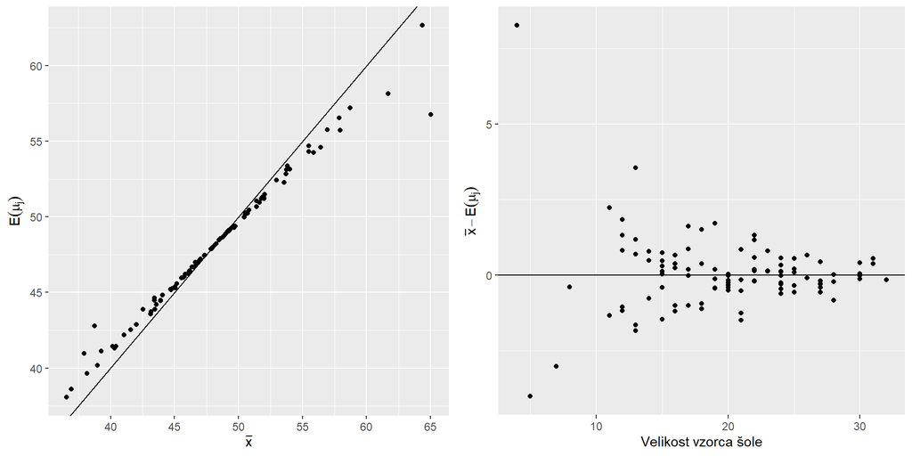

Velikih razlik v primerjavi s prvotnim modelom pravzaprav ni videti. Je pa lepo videti *shrinkage* efekt, ki pokaže kako skupine ki bolj odstopajo od povprečja, jih bolj “popravimo” s skupinskim povprečjem $\mu$. Podobno je videti na sosednji sliki kako skupine z manjšim številom zapisov bolj “popravimo” (ker jim manj verjamemo) medtem ko večje skupine pa manj.

Poglejmo si še podobne slike za variance skupin.

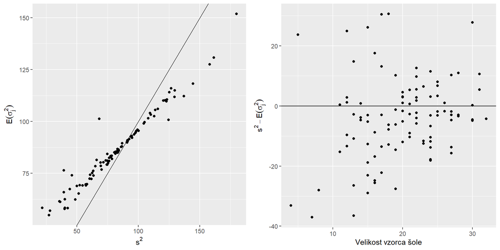

Na prvi sliki je videti podobno stvar kot v prejšnjem primeru, da bolj “ekstremne” primere bolj “skrčimo” k pričakovani vrednosti skupne variance. Zdi se mi da velikost skupine v temu primeru veliko manj vpliva na to koliko “skrčimo” varianco, je pa to še vedno opaziti.

# 5. Primerjajava

Če primerjamo rezultate modela iz vaj in trenutnega modela, vidimo da pri rezultatih za povprečja ($\mu$ in $\eta^2$) večjih razlik pravzaprav ni. Torej ko smo dodali varianco za posamezne skupine, nismo veliko prispevali k tem porazdelitvam. Smo pa z upeljavo varianc posameznih šol pridobili dodatno informacijo o šoli, medtem ko smo prej predpostavili da so variance za vse šole enake.

Model z različnimi variancami je, po mojem mnenju, smiselno uporabiti v primerih ko nas zanimajo tudi parametri o variancah. V temu primeru (o šolah), bi rekel da ne vidim razloga da ne bi uporabili modela z različnimi variancami. Računsko se mi ne zdi veliko bolj potraten, da bi lahko upravičili neuporabo modela z različnimi variancami. Če nas pa zanimajo samo povprečja, in če je tudi podatkov precej več, in je potrebnih več iteracij, je pa smiselno razmisliti o temu da uporabimo prvotno različico modela, saj ne bi storili velike napake pri izračunavanju parametrov za povprečja.